# Life Insurance Mathematics Assignment 3.0

Jongseo Im (11839546), Lotte Bulder (12387584), Desiree Rashedy (12249351), Richard Cornelisse (12367885)

29/8/2019

## Question 1

*This part was performed and completed during the seminar by each listed member of this group.*

## Question 2a

*(Makeham’s mortality law) Makeham’s mortality law with A= 0.00022,B= 2.7·10−6,c= 1.124 implies that <sub>t</sub> p<sub>x</sub> can be written as: <sub>t</sub> p<sub>x</sub>* $=s^{t}*g^{c^{x}(c^{t}-1)}$ *where* $s=e^{-A}$ *and* $g=e^{\frac{-B}{log(c)}}$. *This can be proven by the following deravtion below:*

$$_{t}p_{x}= e^{-\left(\int_{0}^{t} (A+B*C^{x+r}) \; dr\right)}$$
$$_{t}p_{x}= e^{-\left(\int_{0}^{t} A \; dr\right)+ \left(\int_{0}^{t} (B*C^{x+r})\; dr\right)}$$
$$_{t}p_{x}= e^{\left. [A*r \right|_{a}^{b}+ B*C^{x}\left(\int_{0}^{t} C^{r}\; dr\right)}$$
$$_{t}p_{x}= e^{\left. [A*r \right|_{a}^{b}+ B*C^{x}\left. [\frac{C^{r}}{log(C)}] \right|_{0}^{t}}$$
$$_{t}p_{x}= e^{A*t+B*C^{x}*(\frac{C^{r}-1}{log(C)})}$$
$$_{t}p_{x}= e^{A*t}e^{\frac{-B}{log(C)}*C^{x}*(C^{t}-1)}$$
$$_{t}p_{x}=S^{t}*g^{C^{x}*(C^{t}-1)}$$

## Question 2b

*Visualize the survival function Sx(t) = <sub>t</sub> p<sub>x</sub> versus t for a set of ages x. In order to do so we’ve made the following script:*  
*First we defined all our constants:*

```r
A <- 0.00022
B <- 2.7*(10^(-6))
c <- 1.124
s <- exp(-A)
g <- exp(-B/(log(c)))
t <- seq(0,115)
#set of ages x has been set to 6 groups of equal width 15.
age <- c(15,30,45,60,75,90)
```

*Now we can start creating a vector for tpx using the constants above:*

```r
tPx = matrix(
    c((s^t)*(g^((c^age[1])*((c^t)-1))),
      (s^t)*(g^((c^age[2])*((c^t)-1))),
      (s^t)*(g^((c^age[3])*((c^t)-1))),
      (s^t)*(g^((c^age[4])*((c^t)-1))),
      (s^t)*(g^((c^age[5])*((c^t)-1))),
      (s^t)*(g^((c^age[6])*((c^t)-1)))),
      nrow=6, ncol=116,byrow=TRUE)
```

*Having everyting defined we are able to plot the graph of tpx vs t:*

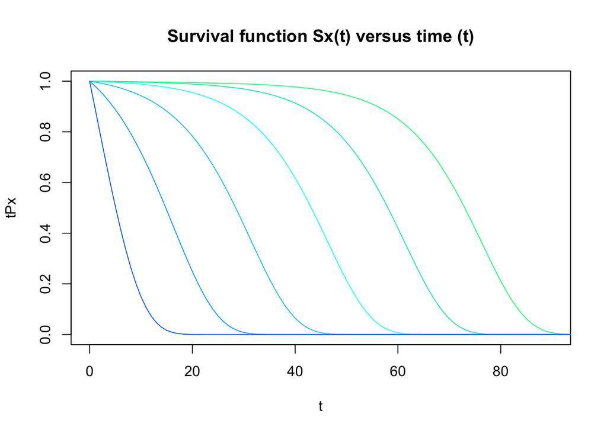

```r
plot(t,tPx[1,],main="Survival function Sx(t) versus time (t)" ,ylim=c(0,1),xlim=c(0,90),xlab="t",ylab="tPx",type="l",col="#03FF88") #Green
lines(t,tPx[2,],type="l",col="#0CE8AF") #Blue Green
lines(t,tPx[3,],type="l",col="#00FFF2") #Light Blue
lines(t,tPx[4,],type="l",col="#0CC8E8") #Slighty darker Blue
lines(t,tPx[5,],type="l",col="#00A8FF") #Blue
lines(t,tPx[6,],type="l",col="#0C70E8") #Dark Blue
```

*We can now clearly see that the youngest group starting at age 15 has the hightest probabilities for surviving t more years whilst the oldest group aged 90 has a steep decline in survival probabilities when t increases*

## Question 2c

*For this question we used the population size of Amsterdam to create a life table and choose 115 as our maximum age of living.* *Our first step will be to assign the values of tpx to the 1-qx and start running the simulation to obtain values for lx and dx.*

```r
age <- seq(0,115)
tpx <- (s^1)*(g^((c^age)*((c^1)-1)))
qx <- (1-tpx)
lx <- c(rep(0,116))
lx[1] <- 866686
for(i in 2:116)
  {lx[i] <- round(lx[(i-1)]*tpx[(i-1)])}
dx <- c(rep(0,116))
for(i in 1:115)
  {dx[i] <- lx[i]-lx[(i+1)]}
```

*Now we have created all entries we have to knit it into a structured matrix i.e. the lifetable.*

```r
lifetable <- matrix(c(age,qx,lx,dx),nrow=116, ncol=4)
colnames(lifetable) <- c("age","qx","lx","dx")
rownames(lifetable) <- c(rep("",116))
lifetable
```

```
##  age           qx     lx    dx
##    0 0.0002228393 866686   193
##    1 0.0002231944 866493   193
##    2 0.0002235935 866300   194
##    3 0.0002240421 866106   194
##    4 0.0002245463 865912   194
##    5 0.0002251130 865718   195
##    6 0.0002257500 865523   195
##    7 0.0002264661 865328   196
##    8 0.0002272708 865132   197
##    9 0.0002281754 864935   197
##   10 0.0002291922 864738   198
##   11 0.0002303350 864540   199
##   12 0.0002316195 864341   200
##   13 0.0002330633 864141   201
```

[output cut: 102 more lines]

## Question 3